# Generations Connect COVID Vaccine Study R Code

Updated **2024-09-20**  
By Runqi Yuan

## Libraries / Packages

First let’s call in the libraries/packages.  
If not working, try install them and run again.

```r
library(foreign)
library(haven)
library(sjlabelled)
library(MASS)
library(sjPlot)
library(brant)
library(VGAM)
library(car)
library(ordinal)
library(dplyr)
library(tidyr)
library(ggplot2)
library(forcats)
```

## Import and seed

Set a seed and import the dataset.  
Remember to first `set working directory` (not shown here) to the correct folder where you placed your dataset file.

```r
set.seed(2024)
covid <- read_sav("COVIDOUTCOMEP123ET1SHORT.sav")
```

## Prepare the dataset.

### Preparing the DV

Our dependent variable (**DV**) is COVID vaccine dosage (“**Dosage**”).  
Older adults received: `< 3 doses`; `3 doses`; `> 3 doses` of COVID-19 vaccine. Those **3** levels should be ordered.  
Make sure our DV is recognized as a ordered factor because we are going for *ordinal logistic regression*.

```r
covid$Dosage <- as_factor(covid$Dosage, ordered = TRUE)
covid$Dosage_nozero <- as_factor(covid$Dosage_nozero, ordered = TRUE)
```

Note `Dosage_nozero` is a special-case DV. It does **not** contain cases that received 0 doses. We may or may not explore this DV within this file.

Our source file was an imported SPSS `.sav` file. Labeling from SPSS may interfere with R processing. Transform applicable categorical variables into factors.

```r
# Treat haven label for categorical variables, if Haven is causing trouble
class(covid$cssa)
```

```
## [1] "haven_labelled" "vctrs_vctr"     "double"
```

```r
class(covid$gender)
```

```
## [1] "haven_labelled" "vctrs_vctr"     "double"
```

```r
# List of variable names to be converted to factors
factor_vars <- c( "region", "NGO","gender", "education","marital","income", "cssa","employment","public_housing",
                  "living_with_family", "joined_dhc", "eat_meat", "extra_seasoning", "smoking",
                  "drinking", "drinking", "going_out", "get_online_health_info", "H01", "RAT",
                  "own_phone",
                  "married", "widowed", "recommended_exercise"

)
# Convert specified variables to factors
covid <- covid %>%
  mutate(across(all_of(factor_vars), ~ factor(.)))
#
class(covid$cssa)
```

```
## [1] "factor"
```

```r
class(covid$gender)
```

```
## [1] "factor"
```

### Preparing the IV: demographics

Similarly, let’s make sure we get to see which level is significant, compared to the reference level. (Sometimes model output omits detailed levels)

```r
covid$region <- factor(covid$region, levels = 1:3, labels = c("1HK", "2KL", "3NT"))
covid$education <- factor(covid$education, levels = 1:3, labels = c("3Tertiary", "2Secondary", "1Primary or below"))
covid$marital <- factor(covid$marital, levels = 1:4, labels = c("1Single", "2Married", "3Divorced", "4Widowed"))
covid$income <- factor(covid$income, levels = 0:2, labels = c("1No Income", "1Less Than 25K", "More than 25K"))
covid$employment <- factor(covid$employment, levels = 1:5, labels = c("1Full Time", "2Part Time", "3Retired", "4Unemployed", "5Houswife"))
covid$marital <- relevel(covid$marital, ref = 2)
```

Some other categorical predictors need this similar treatment as well. We will do this when we get there.

### Identify and Address Multicollinearity

#### Diagnose VIF

```r
linear_model <- lm(as.numeric(Dosage) ~ region + NGO + gender + age + gender * age + education + marital + income + cssa + employment + public_housing + living_with_family + physical_wellbeing + joined_dhc + bad_eats + good_eats + personal_happiness + family_happiness + going_out + recommended_exercise + WHO5 + UCLA3 + eHEALS, data = covid)

vif_values <- vif(linear_model)
```

```
## there are higher-order terms (interactions) in this model
## consider setting type = 'predictor'; see ?vif
```

```r
print(vif_values)
```

```
##                            GVIF Df GVIF^(1/(2*Df))
## region                 5.231734  2        1.512382
## NGO                   11.076836 18        1.069083
## gender               124.143267  1       11.141960
## age                    3.796695  1        1.948511
## education              1.257602  2        1.058975
## marital                2.376826  3        1.155224
## income                 1.174019  2        1.040923
## cssa                   1.190686  1        1.091186
## employment             1.150639  4        1.017694
## public_housing         1.513778  1        1.230357
## living_with_family     2.159461  1        1.469511
## physical_wellbeing     1.246575  1        1.116501
## joined_dhc             1.223537  1        1.106136
## bad_eats               1.055466  1        1.027359
## good_eats              1.088826  1        1.043468
## personal_happiness     2.478069  1        1.574188
## family_happiness       1.991736  1        1.411289
## going_out              1.544265  3        1.075112
## recommended_exercise   1.495436  2        1.105839
## WHO5                   2.232125  1        1.494030
## UCLA3                  1.487952  1        1.219816
## eHEALS                 1.208503  1        1.099319
## gender:age           121.387669  1       11.017607
```

By introducing an interaction term of `gender*age`, We seem to have a quite high VIF (Variance Inflation Factor).  
A VIF > 10 may be a sign for problematic multicollinearity.

#### What if no interaction term?

```r
linear_model <- lm(as.numeric(Dosage) ~ region + NGO + gender + age + education + marital + income + cssa + employment + public_housing + living_with_family + physical_wellbeing + joined_dhc + bad_eats + good_eats + personal_happiness + family_happiness + going_out + recommended_exercise + WHO5 + UCLA3 + eHEALS, data = covid)

vif_values <- vif(linear_model)
print(vif_values)
```

```
##                           GVIF Df GVIF^(1/(2*Df))
## region                5.230224  2        1.512273
## NGO                  11.011761 18        1.068908
## gender                1.244602  1        1.115617
## age                   1.377273  1        1.173573
## education             1.257555  2        1.058965
## marital               2.353804  3        1.153352
## income                1.173807  2        1.040877
## cssa                  1.189362  1        1.090579
## employment            1.149796  4        1.017601
## public_housing        1.511910  1        1.229598
## living_with_family    2.155747  1        1.468246
## physical_wellbeing    1.246568  1        1.116498
## joined_dhc            1.223479  1        1.106110
## bad_eats              1.054580  1        1.026927
## good_eats             1.088440  1        1.043283
## personal_happiness    2.477424  1        1.573984
## family_happiness      1.989868  1        1.410627
## going_out             1.542838  3        1.074946
## recommended_exercise  1.495035  2        1.105765
## WHO5                  2.227975  1        1.492640
## UCLA3                 1.487583  1        1.219665
## eHEALS                1.208389  1        1.099267
```

Once we remove the interaction, the VIF looks okay! Seems like it indeed was the **introduction of the** `gender*age` **interaction term** that caused us some trouble.  
Mean-centering can remedy this situation. Additionally, mean-centering `age` helps make `age` more interpretable: now the effect of other predictors is when `age` is held at mean value instead of 0 (which as you know, 0-years old makes little intuitive sense in this study!).

#### Mean-center age, gender and a new interaction term with the centered variables

```r
covid$age_centered <- scale(covid$age, scale = FALSE)
covid$gender_numeric <- as.numeric(covid$gender) - 1  #1 = male, 2 = female
covid$gender_centered <- scale(covid$gender_numeric, scale = FALSE)

covid$interaction_centered <- covid$age_centered * covid$gender_centered

head(covid[, c("age_centered", "gender_centered", "interaction_centered")])
```

```
## # A tibble: 6 × 3
##   age_centered[,1] gender_centered[,1] interaction_centered[,1]
##              <dbl>               <dbl>                    <dbl>
## 1           -3.66               -0.739                    2.70
## 2           -6.66                0.261                   -1.74
## 3           -0.656               0.261                   -0.171
## 4           -7.66                0.261                   -2.00
## 5          -10.7                 0.261                   -2.78
## 6           -0.656              -0.739                    0.485
```

#### Verify VIF of the centered variables

```r
centered_linear_model <- lm(as.numeric(Dosage) ~ region + NGO + gender_centered * age_centered + education + marital + income + cssa + employment + public_housing + living_with_family + physical_wellbeing + joined_dhc + bad_eats + good_eats + personal_happiness + family_happiness + going_out + recommended_exercise + WHO5 + UCLA3 + eHEALS, data = covid)

vif_values_centered <- vif(centered_linear_model)
```

```
## there are higher-order terms (interactions) in this model
## consider setting type = 'predictor'; see ?vif
```

```r
print(vif_values_centered)
```

```
##                                   GVIF Df GVIF^(1/(2*Df))
## region                        5.231734  2        1.512382
## NGO                          11.076836 18        1.069083
## gender_centered               1.259951  1        1.122475
## age_centered                  1.392147  1        1.179893
## education                     1.257602  2        1.058975
## marital                       2.376826  3        1.155224
## income                        1.174019  2        1.040923
## cssa                          1.190686  1        1.091186
## employment                    1.150639  4        1.017694
## public_housing                1.513778  1        1.230357
## living_with_family            2.159461  1        1.469511
## physical_wellbeing            1.246575  1        1.116501
## joined_dhc                    1.223537  1        1.106136
## bad_eats                      1.055466  1        1.027359
## good_eats                     1.088826  1        1.043468
## personal_happiness            2.478069  1        1.574188
## family_happiness              1.991736  1        1.411289
## going_out                     1.544265  3        1.075112
## recommended_exercise          1.495436  2        1.105839
## WHO5                          2.232125  1        1.494030
## UCLA3                         1.487952  1        1.219816
## eHEALS                        1.208503  1        1.099319
## gender_centered:age_centered  1.073505  1        1.036101
```

`gender_centered:age_centered` is the centered interaction term. Its VIF now looks normal!

## The Analysis

### Basic ordinal logistic regression models that assume **proportional odds**

We first explore the basic, proportional odds assumption models.  
In the context of our dataset: remember we have **3 levels** within our **DV**:  
`< 3 doses`,  
`= 3 doses`, and  
`> 3 doses`.  
In ordinal logistic regression, we study what effects a predictor has on the DV:  
Will this predictor make it more, or less likely to **be in a higher category**.  
By proportional odds, we assume that this likelihood applies equally to all thresholds:  
It is equally likely to move from `<3 doses` to `=3 doses`, and `=3 doses` to `>3 doses`.  
We cross **2** thresholds with **3** levels, but the likelihood (the estimates we get) when crossing **2** thresholds are assumed to stay the same.

#### Using `polr()`

When we assume this, we can calculate by using `polr()`:

```r
attach(covid)
class(Dosage)
```

```
## [1] "ordered" "factor"
```

```r
class(Dosage_nozero)
```

```
## [1] "ordered" "factor"
```

```r
basic_formula <- Dosage ~ region + gender_centered + age_centered + interaction_centered + education + marital + income +
                                 public_housing + living_with_family
basic_model <- polr(basic_formula, data = covid, method = "logistic")
summary(basic_model)
```

```
##
## Re-fitting to get Hessian
```

```
## Call:
## polr(formula = basic_formula, data = covid, method = "logistic")
##
## Coefficients:
##                               Value Std. Error t value
## region2KL                  -0.07734   0.100304 -0.7711
## region3NT                  -0.09794   0.086025 -1.1385
## gender_centered            -0.14706   0.086799 -1.6942
## age_centered               -0.01696   0.005498 -3.0855
## interaction_centered        0.02183   0.011113  1.9645
## education2Secondary        -0.21575   0.166067 -1.2992
## education1Primary or below -0.40144   0.162495 -2.4705
## marital1Single             -0.08575   0.175302 -0.4892
## marital3Divorced            0.07781   0.168074  0.4629
## marital4Widowed            -0.09623   0.102985 -0.9344
## income1Less Than 25K       -0.15822   0.085286 -1.8551
## incomeMore than 25K         0.06022   0.191784  0.3140
## public_housing1            -0.25666   0.079363 -3.2339
## living_with_family1         0.01325   0.098931  0.1339
##
## Intercepts:
##                           Value    Std. Error t value
## Less Than 3 Doses|3 Doses  -2.6280   0.1947   -13.4963
## 3 Doses|More Than 3 Doses   0.1468   0.1876     0.7826
##
## Residual Deviance: 5878.808
## AIC: 5910.808
## (91 observations deleted due to missingness)
```

#### Using `clm()`

Or we can use `clm()`. Results should agree.

```r
basic_model2 <- clm(Dosage ~ region + gender_centered + age_centered + interaction_centered + education + marital + income +
                                 public_housing + living_with_family ,
                               data = covid, link = "logit")

summary(basic_model2)
```

```
## formula:
## Dosage ~ region + gender_centered + age_centered + interaction_centered + education + marital + income + public_housing + living_with_family
## data:    covid
##
##  link  threshold nobs logLik   AIC     niter max.grad cond.H
##  logit flexible  3138 -2939.40 5910.81 5(0)  2.08e-07 4.6e+03
##
## Coefficients:
##                             Estimate Std. Error z value Pr(>|z|)
## region2KL                  -0.077349   0.100304  -0.771  0.44062
## region3NT                  -0.097951   0.086025  -1.139  0.25485
## gender_centered            -0.147071   0.086799  -1.694  0.09019 .
## age_centered               -0.016962   0.005498  -3.085  0.00203 **
## interaction_centered        0.021829   0.011113   1.964  0.04949 *
## education2Secondary        -0.215713   0.166067  -1.299  0.19396
## education1Primary or below -0.401412   0.162495  -2.470  0.01350 *
## marital1Single             -0.085755   0.175302  -0.489  0.62471
## marital3Divorced            0.077773   0.168074   0.463  0.64356
## marital4Widowed            -0.096241   0.102984  -0.935  0.35004
## income1Less Than 25K       -0.158239   0.085286  -1.855  0.06354 .
## incomeMore than 25K         0.060178   0.191784   0.314  0.75369
## public_housing1            -0.256684   0.079363  -3.234  0.00122 **
## living_with_family1         0.013235   0.098931   0.134  0.89357
## ---
## Signif. codes:  0 '***' 0.001 '**' 0.01 '*' 0.05 '.' 0.1 ' ' 1
##
## Threshold coefficients:
##                           Estimate Std. Error z value
## Less Than 3 Doses|3 Doses  -2.6280     0.1947 -13.496
## 3 Doses|More Than 3 Doses   0.1467     0.1876   0.782
## (91 observations deleted due to missingness)
```

```r
basic2_odds_ratios <- exp(coef(basic_model2))
print(basic2_odds_ratios)
```

```
##  Less Than 3 Doses|3 Doses  3 Doses|More Than 3 Doses
##                 0.07222387                 1.15806122
##                  region2KL                  region3NT
##                 0.92556665                 0.90669312
##            gender_centered               age_centered
##                 0.86323308                 0.98318086
##       interaction_centered        education2Secondary
##                 1.02206885                 0.80596686
## education1Primary or below             marital1Single
##                 0.66937403                 0.91781935
##           marital3Divorced            marital4Widowed
##                 1.08087743                 0.90824528
##       income1Less Than 25K        incomeMore than 25K
##                 0.85364534                 1.06202517
##            public_housing1        living_with_family1
##                 0.77361229                 1.01332329
```

```r
basic2_conf_int <- exp(confint(basic_model2, level = 0.95))
print(basic2_conf_int)
```

```
##                                2.5 %    97.5 %
## region2KL                  0.7603318 1.1266363
## region3NT                  0.7660016 1.0732422
## gender_centered            0.7281448 1.0233150
## age_centered               0.9726333 0.9938250
## interaction_centered       1.0000567 1.0445915
## education2Secondary        0.5818443 1.1161619
## education1Primary or below 0.4866470 0.9205743
## marital1Single             0.6505841 1.2937478
## marital3Divorced           0.7771796 1.5023538
## marital4Widowed            0.7421585 1.1113381
## income1Less Than 25K       0.7220926 1.0087981
## incomeMore than 25K        0.7287626 1.5465927
## public_housing1            0.6621150 0.9037715
## living_with_family1        0.8346703 1.2301687
```

As we can see here: When only including demographics in our model, `age`, `interaction`, `education` (only level: primary or below) and `public housing` were significant predictors:  
`Coefficients: Estimate Std. Error z value Pr(>|z|)`  
`age_centered -0.016962 0.005498 -3.085 0.00203 **`  
`education1Primary or below -0.401412 0.162495 -2.470 0.01350 *`  
`public_housing -0.256684 0.079363 -3.234 0.00122 **`

We can also create a custom function to show odds ratio in a forest plot:

```r
# Custom function for forest plot
# notice VGAM give intercept in both OR and CI
create_forest_plot <- function(model) {

  odds_ratios <- exp(coef(model))
  conf_int <- exp(confint(model))

  # Remove intercepts from odds_ratios
  odds_ratios_no_intercept <- odds_ratios[-c(1:2)]

  or_df <- data.frame(
    Predictor = names(odds_ratios_no_intercept),
    OR = odds_ratios_no_intercept,
   Lower_CI = conf_int[, 1],
   Upper_CI = conf_int[, 2]
  )
  or_df$Predictor <- fct_rev(factor(or_df$Predictor, levels = names(odds_ratios)))
  or_df$OR_CI_Label <- sprintf("%.2f (%.2f, %.2f)", or_df$OR, or_df$Lower_CI, or_df$Upper_CI)
  or_df$Significant <- ifelse(or_df$Lower_CI > 1 | or_df$Upper_CI < 1, TRUE, FALSE)

  # Create the forest plot using ggplot2
  ggplot(or_df, aes(x = OR, y = Predictor, OR)) +
    geom_point(aes(color = Significant), size = 3) +  # Highlight significant points in color
    geom_errorbarh(aes(xmin = Lower_CI, xmax = Upper_CI, color = Significant), height = 0.2) +  # Add horizontal error bars
    geom_vline(xintercept = 1, linetype = "dashed", color = "red") +  # Add vertical line at OR = 1 for reference
    geom_text(aes(label = OR_CI_Label, x = OR, y = Predictor), hjust = -0.2, vjust = 1.2, size = 3) +  # Add OR and CI labels
    scale_color_manual(values = c("FALSE" = "grey", "TRUE" = "blue")) +  # Color significant points blue

   labs(x = "Odds Ratio (log scale)",
        y = "Predictor",
        title = "Forest Plot of Odds Ratios and 95% Confidence Intervals") +
   scale_x_log10() +  # Log scale for odds ratios
   theme_minimal()+
    theme(
      plot.margin = margin(10, 20, 10, 20),  # Add padding to all sides of the plot
      legend.position = "none"  # Remove legend for significance coloring
    )


}
```

Now call the function:

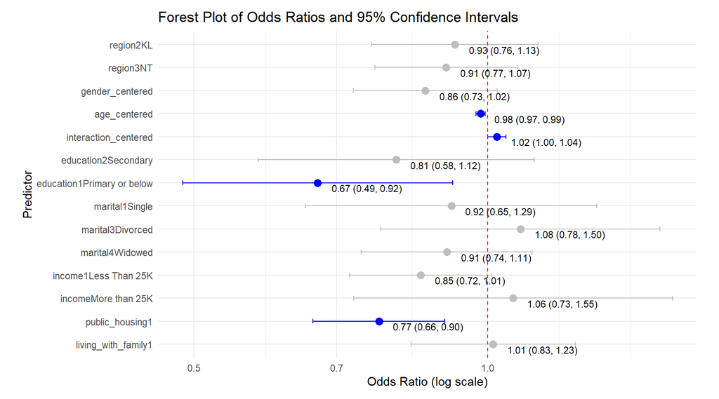

```r
create_forest_plot(basic_model2)
```

Based on the estimates and the plot, we see that the direction of estimates met our expectations: participants who are *older*, *less educated*, *living in public housing* seem to receive fewer doses, which aligns well with what we generally know about older adult population.  
But **does the proportional odds assumption actually hold?**

#### Testing proportional odds assumption

We can check this assumption with Brant test using `brant()`

```r
brant_basic <- brant(basic_model)
```

```
## ------------------------------------------------------------
## Test for         X2  df  probability
## ------------------------------------------------------------
## Omnibus              36.29   14  0
## region2KL            0.34    1   0.56
## region3NT            0.79    1   0.37
## gender_centered      1.44    1   0.23
## age_centered         17.16   1   0
## interaction_centered     0.59    1   0.44
## education2Secondary      0.46    1   0.5
## education1Primary or below   4.37    1   0.04
## marital1Single           1.36    1   0.24
## marital3Divorced     0   1   0.99
## marital4Widowed      0   1   0.96
## income1Less Than 25K     0.28    1   0.6
## incomeMore than 25K      0.43    1   0.51
## public_housing1      0.18    1   0.67
## living_with_family1      1.08    1   0.3
## ------------------------------------------------------------
##
## H0: Parallel Regression Assumption holds
```

```r
print(brant_basic)
```

```
##                                      X2 df  probability
## Omnibus                    3.628537e+01 14 9.455272e-04
## region2KL                  3.358089e-01  1 5.622584e-01
## region3NT                  7.900941e-01  1 3.740717e-01
## gender_centered            1.437810e+00  1 2.304941e-01
## age_centered               1.716238e+01  1 3.431663e-05
## interaction_centered       5.913692e-01  1 4.418901e-01
## education2Secondary        4.566133e-01  1 4.992110e-01
## education1Primary or below 4.374385e+00  1 3.648300e-02
## marital1Single             1.355048e+00  1 2.443975e-01
## marital3Divorced           2.282527e-04  1 9.879460e-01
## marital4Widowed            2.055875e-03  1 9.638349e-01
## income1Less Than 25K       2.793628e-01  1 5.971192e-01
## incomeMore than 25K        4.301821e-01  1 5.118996e-01
## public_housing1            1.812521e-01  1 6.702994e-01
## living_with_family1        1.078135e+00  1 2.991151e-01
```

The results of the Brant test shows `age`, `education` (and the `omnibus` test) were significant. The assumption is **unlikely** to hold.  
Additionally, consider the context and theoretical background of this dataset.  
It is not practical to assume that older adults’ motivation behind vaccination behavior, especially about **change** in such behavior, is same for changing from`<3 doses` to `=3 doses` (which is government mandate), and from `=3 doses` to `>3 doses`. A model that does not require such assumption is preferred.  
Meet **Generalized Ordered Logit Model**.

### Generalized Ordered Logit Model (w/o proportional odds assumption) using `vglm()`

#### 1 Demographics-only

The generalized ordered logit model (or cumulative logistic regression model) will break the assumption where “two thresholds should hold same value”, and allow the predictors to have **different estimates** upon two thresholds.  
Demographics-only model using `vglm()`.  
**Be advised**: by default this model assumes you will compare *lower* DV category against *higher*. Use `reverse = TRUE` argument to flip that back. Also pay attention to what exactly the **estimates/probability** means: It is not the predictor that gained more levels; it is the DV!

```r
cumulative_basic_model <- vglm(Dosage ~ region + gender_centered + age_centered + interaction_centered + education + marital + income +
                              public_housing + living_with_family,
                            family = cumulative(link = "logitlink",parallel = FALSE, reverse = TRUE), data = covid)

summary(cumulative_basic_model)
```

```
##
## Call:
## vglm(formula = Dosage ~ region + gender_centered + age_centered +
##     interaction_centered + education + marital + income + public_housing +
##     living_with_family, family = cumulative(link = "logitlink",
##     parallel = FALSE, reverse = TRUE), data = covid)
##
## Coefficients:
##                               Estimate Std. Error z value Pr(>|z|)
## (Intercept):1                 2.350856   0.296665   7.924 2.29e-15 ***
## (Intercept):2                -0.085653   0.197989  -0.433  0.66530
## region2KL:1                  -0.145844   0.157711  -0.925  0.35509
## region2KL:2                  -0.045579   0.111604  -0.408  0.68298
## region3NT:1                  -0.179779   0.137518  -1.307  0.19111
## region3NT:2                  -0.056710   0.094810  -0.598  0.54975
## gender_centered:1            -0.008311   0.142359  -0.058  0.95344
## gender_centered:2            -0.192867   0.093633  -2.060  0.03941 *
## age_centered:1               -0.041775   0.008318  -5.023 5.10e-07 ***
## age_centered:2               -0.005536   0.006084  -0.910  0.36284
## interaction_centered:1        0.009485   0.016947   0.560  0.57568
## interaction_centered:2        0.024300   0.012144   2.001  0.04540 *
## education2Secondary:1        -0.058333   0.260809  -0.224  0.82302
## education2Secondary:2        -0.232092   0.171341  -1.355  0.17556
## education1Primary or below:1  0.031641   0.253752   0.125  0.90077
## education1Primary or below:2 -0.516656   0.168061  -3.074  0.00211 **
## marital1Single:1             -0.286761   0.259555  -1.105  0.26924
## marital1Single:2              0.007479   0.190385   0.039  0.96866
## marital3Divorced:1            0.097055   0.279934   0.347  0.72881
## marital3Divorced:2            0.077587   0.183403   0.423  0.67226
## marital4Widowed:1            -0.087180   0.159405  -0.547  0.58444
## marital4Widowed:2            -0.097179   0.116124  -0.837  0.40267
## income1Less Than 25K:1       -0.102880   0.132451  -0.777  0.43731
## income1Less Than 25K:2       -0.183243   0.096612  -1.897  0.05787 .
## incomeMore than 25K:1        -0.079427   0.312041  -0.255  0.79908
## incomeMore than 25K:2         0.114279   0.206049   0.555  0.57915
## public_housing1:1            -0.313489   0.130283  -2.406  0.01612 *
## public_housing1:2            -0.239526   0.086526  -2.768  0.00564 **
## living_with_family1:1         0.144618   0.152453   0.949  0.34282
## living_with_family1:2        -0.033074   0.111277  -0.297  0.76630
## ---
```

[output cut: 27 more lines]

```
##                    1.0321465                    0.5965122
##             marital1Single:1             marital1Single:2
##                    0.7506911                    1.0075074
##           marital3Divorced:1           marital3Divorced:2
##                    1.1019206                    1.0806764
##            marital4Widowed:1            marital4Widowed:2
##                    0.9165119                    0.9073940
##       income1Less Than 25K:1       income1Less Than 25K:2
##                    0.9022350                    0.8325656
##        incomeMore than 25K:1        incomeMore than 25K:2
##                    0.9236458                    1.1210647
##            public_housing1:1            public_housing1:2
##                    0.7308923                    0.7870006
##        living_with_family1:1        living_with_family1:2
##                    1.1555981                    0.9674672
```

```r
cumulative_basic_ci <- exp(confint(cumulative_basic_model, level = 0.95))
print(cumulative_basic_ci)
```

```
##                                  2.5 %     97.5 %
## (Intercept):1                5.8673533 18.7709022
## (Intercept):2                0.6226921  1.3530996
## region2KL:1                  0.6344782  1.1773481
## region2KL:2                  0.7677289  1.1890564
## region3NT:1                  0.6380693  1.0939021
## region3NT:2                  0.7846372  1.1378206
## gender_centered:1            0.7502648  1.3108904
## gender_centered:2            0.6863389  0.9906929
## age_centered:1               0.9435766  0.9748484
## age_centered:2               0.9826921  1.0064082
## interaction_centered:1       0.9765494  1.0436251
## interaction_centered:2       1.0004981  1.0492767
## education2Secondary:1        0.5658029  1.5727785
## education2Secondary:2        0.5667066  1.1093008
## education1Primary or below:1 0.6276925  1.6972106
## education1Primary or below:2 0.4291071  0.8292262
## marital1Single:1             0.4513647  1.2485183
## marital1Single:2             0.6937329  1.4632018
## marital3Divorced:1           0.6366056  1.9073488
## marital3Divorced:2           0.7543676  1.5481333
## marital4Widowed:1            0.6705825  1.2526334
## marital4Widowed:2            0.7226886  1.1393065
## income1Less Than 25K:1       0.6959485  1.1696670
## income1Less Than 25K:2       0.6889416  1.0061311
## incomeMore than 25K:1        0.5010672  1.7026091
## incomeMore than 25K:2        0.7485856  1.6788809
## public_housing1:1            0.5661823  0.9435187
## public_housing1:2            0.6642388  0.9324508
## living_with_family1:1        0.8571147  1.5580261
## living_with_family1:2        0.7778886  1.2032478
```

Again, pay attention to the model output where:  
`Names of linear predictors: logitlink(P[Y>=2]), logitlink(P[Y>=3])`  
This means the estimates of the predictors (and odds ratios) were comparing *higher* to *lower*, which is what we usually expect.  
The output seems confusing with every single variable having two lines: `variable:1` and `variable:2`.  
A way that may help understand is by imagining having **two separate** `binomial logistic regressions`.  
The generalized ordered logit model gave us additional insight that was hidden in previous models:  
**Example 1: Gender**  
`Coefficients: Estimate Std. Error z value Pr(>|z|)`  
`gender_centered:1 -0.008311 0.142359 -0.058 0.95344`  
`gender_centered:2 -0.192867 0.093633 -2.060 0.03941 *`  
`Gender` was previous not significant (`p = 0.09`).  
In this new model:  
For `<3 doses` to `=3 doses`, `gender` had no effect.  
But for `=3 doses` to `>3 doses`, `gender` was significant (p`= 0.03`).  
For and only for `=3 doses` to `>3 doses`, females were **less likely** than males to being in a higher category.  
**Example 2: Age**  
`Coefficients: Estimate Std. Error z value Pr(>|z|)`  
`age_centered:1 -0.041775 0.008318 -5.023 5.10e-07 ***`  
`age_centered:2 -0.005536 0.006084 -0.910 0.36284`  
Similarly, `Age` was previously significant (`p = 0.002`).  
But where exactly did this effect play out?  
Turns out, for `<3 doses` to `=3 doses`, `age` was significant (`p = 5.10e-07`). As people get older, they are **less likely** to being in a higher category.  
However, for `=3 doses` to `>3 doses`, age was not significant.  
Age affected decisions to jump from `<3 doses` to `=3 doses` (and it was contributing negatively); but **not** for decisions to jump from `=3 doses` to `>3 doses`.  
**Example 3: Public Housing**  
`Coefficients: Estimate Std. Error z value Pr(>|z|)`  
`public_housing:1 -0.313489 0.130283 -2.406 0.01612 *`  
`public_housing:2 -0.239526 0.086526 -2.768 0.00564 **`  
In this case, `public_housing` is significant for **both** thresholds of the DV, meaning that: for both `<3 doses` to `=3 doses` **AND** `=3 doses` to `>3 doses`, living in public housing **decreases the likelihood** of being in a higher category.  
This is also consistent with the `Brant` test earlier where `p = 0.67` was observed for `public_housing`, meaning this predictor likely did not violate the proportional odds assumption.

**Beware**  
Take note that using generalized ordered logit model **did not contradict** our previous conclusions; rather this model *refined* these conclusions, provided us with a more detailed, in-depth view of **where** the change occurred:  
Which one of the thresholds did a certain predictor affect? From `<3 doses` to `=3 doses`? From `=3 doses` to `>3 doses`? Or perhaps both?

Similarly, we can generate an odds ratio plot:

```r
create_forest_plot_vgam <- function(model) {

  odds_ratios <- exp(coef(model))
  conf_int <- exp(confint(model))

  or_df <- data.frame(
    Predictor = names(odds_ratios),
    OR = odds_ratios,
    Lower_CI = conf_int[, 1],
    Upper_CI = conf_int[, 2]
  )

  or_df$Predictor <- fct_rev(factor(or_df$Predictor, levels = names(odds_ratios)))
  or_df$OR_CI_Label <- sprintf("%.2f (%.2f, %.2f)", or_df$OR, or_df$Lower_CI, or_df$Upper_CI)
  or_df$Significant <- ifelse(or_df$Lower_CI > 1 | or_df$Upper_CI < 1, TRUE, FALSE)

  # Create the forest plot using ggplot2
  ggplot(or_df, aes(x = OR, y = Predictor, OR)) +
    geom_point(aes(color = Significant), size = 3) +  # Highlight significant points in color
    geom_errorbarh(aes(xmin = Lower_CI, xmax = Upper_CI, color = Significant), height = 0.2) +  # Add horizontal error bars
    geom_vline(xintercept = 1, linetype = "dashed", color = "red") +  # Add vertical line at OR = 1 for reference
    geom_text(aes(label = OR_CI_Label, x = OR, y = Predictor), hjust = -0.2, vjust = 1.2, size = 3) +  # Add OR and CI labels
    scale_color_manual(values = c("FALSE" = "grey", "TRUE" = "blue")) +  # Color significant points blue

    labs(x = "Odds Ratio (log scale)",
         y = "Predictor",
         title = "Forest Plot of Odds Ratios and 95% Confidence Intervals") +
    scale_x_log10() +  # Log scale for odds ratios
    theme_minimal()+
    theme(
      plot.margin = margin(10, 20, 10, 20),  # Add padding to all sides of the plot
      legend.position = "none"  # Remove legend for significance coloring
    )


}
```

Calling the function:

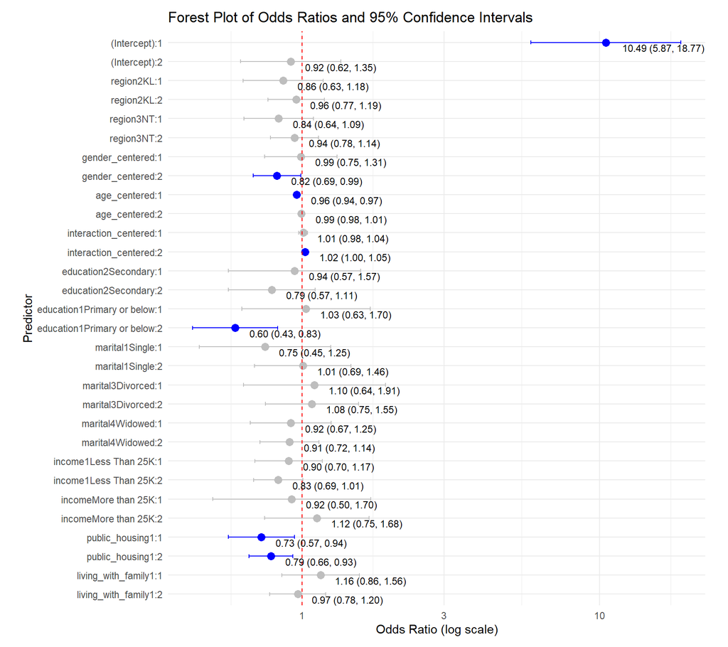

```r
create_forest_plot_vgam(cumulative_basic_model)
```

#### 2 Demographics + Happiness and Mental

Demographics + 1 area of selective predictors.  
Note how we make sure a predictor get its levels declared.

```r
options(width = 110)
covid$going_out <-factor(covid$going_out, levels = 0:3, labels = c("0Less than once a week", "1one or two days", "2three to four days", "3more than four days a week"))

cumulative_model_mental <- vglm(Dosage ~ region + gender_centered + age_centered + interaction_centered + education + marital + income +
                                  public_housing + living_with_family +
                                  personal_happiness + family_happiness + going_out + WHO5 + UCLA3,
                               family = cumulative(link = "logitlink",parallel = FALSE, reverse = TRUE), data = covid)

summary(cumulative_model_mental)
```

```
##
## Call:
## vglm(formula = Dosage ~ region + gender_centered + age_centered +
##     interaction_centered + education + marital + income + public_housing +
##     living_with_family + personal_happiness + family_happiness +
##     going_out + WHO5 + UCLA3, family = cumulative(link = "logitlink",
##     parallel = FALSE, reverse = TRUE), data = covid)
##
## Coefficients:
##                                         Estimate Std. Error z value Pr(>|z|)
## (Intercept):1                           1.042421   0.529933   1.967  0.04917 *
## (Intercept):2                          -0.795036   0.429061  -1.853  0.06389 .
## region2KL:1                            -0.181825   0.160811  -1.131  0.25819
## region2KL:2                            -0.083207   0.114060  -0.730  0.46570
## region3NT:1                            -0.207337   0.141602  -1.464  0.14313
## region3NT:2                            -0.091462   0.097605  -0.937  0.34873
## gender_centered:1                      -0.025291   0.146098  -0.173  0.86257
## gender_centered:2                      -0.203019   0.095871  -2.118  0.03421 *
## age_centered:1                         -0.038443   0.008610  -4.465 8.01e-06 ***
## age_centered:2                         -0.001832   0.006307  -0.290  0.77144
## interaction_centered:1                  0.015834   0.017381   0.911  0.36227
## interaction_centered:2                  0.020127   0.012438   1.618  0.10562
## education2Secondary:1                   0.014858   0.262342   0.057  0.95484
## education2Secondary:2                  -0.215153   0.174767  -1.231  0.21829
## education1Primary or below:1            0.085128   0.254199   0.335  0.73771
## education1Primary or below:2           -0.532035   0.171540  -3.102  0.00193 **
## marital1Single:1                       -0.219439   0.262960  -0.834  0.40400
## marital1Single:2                        0.073845   0.195439   0.378  0.70555
## marital3Divorced:1                      0.206143   0.287836   0.716  0.47388
## marital3Divorced:2                      0.060106   0.187983   0.320  0.74917
## marital4Widowed:1                      -0.005618   0.162172  -0.035  0.97237
## marital4Widowed:2                      -0.105600   0.118362  -0.892  0.37230
## income1Less Than 25K:1                 -0.116735   0.135384  -0.862  0.38855
## income1Less Than 25K:2                 -0.178066   0.098809  -1.802  0.07153 .
## incomeMore than 25K:1                  -0.158349   0.315678  -0.502  0.61594
## incomeMore than 25K:2                   0.155154   0.208369   0.745  0.45651
## public_housing1:1                      -0.317338   0.133744  -2.373  0.01766 *
## public_housing1:2                      -0.234431   0.088794  -2.640  0.00829 **
## living_with_family1:1                   0.170939   0.157343   1.086  0.27730
## living_with_family1:2                  -0.027124   0.115049  -0.236  0.81362
```

[output cut: 56 more lines]

```
##                              1.1864182                              0.9732403
##                   personal_happiness:1                   personal_happiness:2
##                              0.9548995                              0.9949562
##                     family_happiness:1                     family_happiness:2
##                              1.0449629                              0.9858748
##            going_out1one or two days:1            going_out1one or two days:2
##                              1.1770080                              1.4543006
##         going_out2three to four days:1         going_out2three to four days:2
##                              1.5129678                              1.6709180
## going_out3more than four days a week:1 going_out3more than four days a week:2
##                              1.7755438                              1.9147901
##                                 WHO5:1                                 WHO5:2
##                              1.0110092                              1.0032163
##                                UCLA3:1                                UCLA3:2
##                              0.9947130                              1.0064869
```

```r
cumulative_mental_ci <- exp(confint(cumulative_model_mental, level = 0.95))
print(cumulative_mental_ci)
```

```
##                                            2.5 %    97.5 %
## (Intercept):1                          1.0037795 8.0130351
## (Intercept):2                          0.1947616 1.0469773
## region2KL:1                            0.6083470 1.1426600
## region2KL:2                            0.7358263 1.1506730
## region3NT:1                            0.6157762 1.0727211
## region3NT:2                            0.7536976 1.1049940
## gender_centered:1                      0.7322465 1.2983014
## gender_centered:2                      0.6764328 0.9849973
## age_centered:1                         0.9461833 0.9786632
## age_centered:2                         0.9859071 1.0105847
## interaction_centered:1                 0.9819343 1.0511657
## interaction_centered:2                 0.9957581 1.0455094
## education2Secondary:1                  0.6069415 1.6973000
## education2Secondary:2                  0.5725298 1.1358542
## education1Primary or below:1           0.6616015 1.7920283
## education1Primary or below:2           0.4196869 0.8221580
## marital1Single:1                       0.4795862 1.3444087
## marital1Single:2                       0.7340281 1.5791671
## marital3Divorced:1                     0.6990697 2.1603951
## marital3Divorced:2                     0.7346699 1.5350228
## marital4Widowed:1                      0.7236351 1.3664730
## marital4Widowed:2                      0.7134914 1.1347191
## income1Less Than 25K:1                 0.6824393 1.1602233
## income1Less Than 25K:2                 0.6895419 1.0157184
## incomeMore than 25K:1                  0.4597533 1.5846573
## incomeMore than 25K:2                  0.7762799 1.7568995
## public_housing1:1                      0.5601937 0.9462922
## public_housing1:2                      0.6646696 0.9413901
## living_with_family1:1                  0.8715802 1.6149841
## living_with_family1:2                  0.7767655 1.2194113
## personal_happiness:1                   0.8785490 1.0378853
## personal_happiness:2                   0.9379278 1.0554521
## family_happiness:1                     0.9646839 1.1319226
## family_happiness:2                     0.9301628 1.0449236
## going_out1one or two days:1            0.6171712 2.2446735
## going_out1one or two days:2            0.7670522 2.7572965
## going_out2three to four days:1         0.8126054 2.8169533
## going_out2three to four days:2         0.9199271 3.0349869
## going_out3more than four days a week:1 1.0303849 3.0595906
## going_out3more than four days a week:2 1.1044897 3.3195611
## WHO5:1                                 1.0036778 1.0183940
## WHO5:2                                 0.9978252 1.0086365
## UCLA3:1                                0.9225815 1.0724840
## UCLA3:2                                0.9501556 1.0661579
```

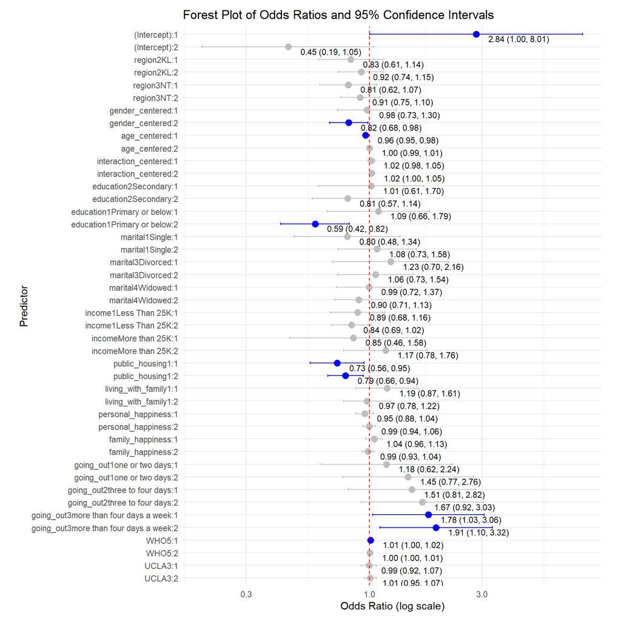

```r
create_forest_plot_vgam(cumulative_model_mental)
```

#### 3 Demographics + Physical

```r
covid$recommended_exercise <-factor(covid$recommended_exercise, levels = 1:3, labels = c("1Less than 150min", "2:150 to 300min", "3Over 300min"))

cumulative_model_phy <- vglm(Dosage ~ region + gender_centered + age_centered + interaction_centered + education + marital + income +
                               public_housing + living_with_family +
                               physical_wellbeing + joined_dhc + recommended_exercise,
                                family = cumulative(link = "logitlink",parallel = FALSE, reverse = TRUE), data = covid)

summary(cumulative_model_phy)
```

```
##
## Call:
## vglm(formula = Dosage ~ region + gender_centered + age_centered +
##     interaction_centered + education + marital + income + public_housing +
##     living_with_family + physical_wellbeing + joined_dhc + recommended_exercise,
##     family = cumulative(link = "logitlink", parallel = FALSE,
##         reverse = TRUE), data = covid)
##
## Coefficients:
##                                        Estimate Std. Error z value Pr(>|z|)
## (Intercept):1                          1.774187   0.374236   4.741 2.13e-06 ***
## (Intercept):2                         -0.434295   0.266687  -1.628 0.103423
## region2KL:1                           -0.171845   0.159620  -1.077 0.281665
## region2KL:2                           -0.083377   0.114618  -0.727 0.466961
## region3NT:1                           -0.170770   0.139414  -1.225 0.220609
## region3NT:2                           -0.081682   0.097343  -0.839 0.401404
## gender_centered:1                     -0.005405   0.144497  -0.037 0.970163
## gender_centered:2                     -0.229580   0.096445  -2.380 0.017293 *
## age_centered:1                        -0.035496   0.008672  -4.093 4.26e-05 ***
## age_centered:2                        -0.002109   0.006408  -0.329 0.742127
## interaction_centered:1                 0.007746   0.017246   0.449 0.653312
## interaction_centered:2                 0.025065   0.012496   2.006 0.044869 *
## education2Secondary:1                 -0.100442   0.266210  -0.377 0.705947
## education2Secondary:2                 -0.303123   0.174707  -1.735 0.082734 .
## education1Primary or below:1          -0.010604   0.258618  -0.041 0.967293
## education1Primary or below:2          -0.572813   0.171168  -3.346 0.000818 ***
## marital1Single:1                      -0.221194   0.269891  -0.820 0.412464
## marital1Single:2                      -0.062928   0.198510  -0.317 0.751245
## marital3Divorced:1                     0.173725   0.287957   0.603 0.546308
## marital3Divorced:2                     0.123760   0.187613   0.660 0.509474
## marital4Widowed:1                     -0.063005   0.161177  -0.391 0.695865
## marital4Widowed:2                     -0.087468   0.118251  -0.740 0.459493
## income1Less Than 25K:1                -0.077397   0.134965  -0.573 0.566334
## income1Less Than 25K:2                -0.184718   0.098853  -1.869 0.061676 .
## incomeMore than 25K:1                 -0.146560   0.316173  -0.464 0.642975
## incomeMore than 25K:2                  0.093099   0.209911   0.444 0.657394
## public_housing1:1                     -0.262025   0.132291  -1.981 0.047628 *
## public_housing1:2                     -0.227825   0.088887  -2.563 0.010375 *
## living_with_family1:1                  0.175316   0.154760   1.133 0.257289
## living_with_family1:2                 -0.057721   0.113673  -0.508 0.611606
```

[output cut: 44 more lines]

```
##                             0.9255224                             0.8313383
##                 incomeMore than 25K:1                 incomeMore than 25K:2
##                             0.8636741                             1.0975698
##                     public_housing1:1                     public_housing1:2
##                             0.7694918                             0.7962636
##                 living_with_family1:1                 living_with_family1:2
##                             1.1916226                             0.9439133
##                  physical_wellbeing:1                  physical_wellbeing:2
##                             1.0933565                             1.0301522
##                         joined_dhc1:1                         joined_dhc1:2
##                             1.4154684                             1.2715032
## recommended_exercise2:150 to 300min:1 recommended_exercise2:150 to 300min:2
##                             0.9617281                             1.1711973
##    recommended_exercise3Over 300min:1    recommended_exercise3Over 300min:2
##                             1.2710256                             1.3605092
```

```r
cumulative_phy_ci <- exp(confint(cumulative_model_phy, level = 0.95))
print(cumulative_phy_ci)
```

```
##                                           2.5 %     97.5 %
## (Intercept):1                         2.8311945 12.2763653
## (Intercept):2                         0.3840463  1.0924276
## region2KL:1                           0.6158852  1.1514300
## region2KL:2                           0.7348971  1.1517365
## region3NT:1                           0.6414549  1.1079119
## region3NT:2                           0.7614965  1.1152809
## gender_centered:1                     0.7493021  1.3202268
## gender_centered:2                     0.6579617  0.9602605
## age_centered:1                        0.9488606  0.9816709
## age_centered:2                        0.9854387  1.0105061
## interaction_centered:1                0.9742814  1.0424229
## interaction_centered:2                1.0005739  1.0508050
## education2Secondary:1                 0.5367600  1.5239711
## education2Secondary:2                 0.5243782  1.0400786
## education1Primary or below:1          0.5960174  1.6425940
## education1Primary or below:2          0.4032107  0.7887314
## marital1Single:1                      0.4722857  1.3604067
## marital1Single:2                      0.6363536  1.3856174
## marital3Divorced:1                    0.6766099  2.0919776
## marital3Divorced:2                    0.7835233  1.6347249
## marital4Widowed:1                     0.6846103  1.2877480
## marital4Widowed:2                     0.7267040  1.1552302
## income1Less Than 25K:1                0.7104026  1.2057836
## income1Less Than 25K:2                0.6849106  1.0090708
## incomeMore than 25K:1                 0.4647539  1.6050064
## incomeMore than 25K:2                 0.7273706  1.6561841
## public_housing1:1                     0.5937419  0.9972644
## public_housing1:2                     0.6689531  0.9478028
## living_with_family1:1                 0.8798459  1.6138785
## living_with_family1:2                 0.7553945  1.1794794
## physical_wellbeing:1                  0.9665406  1.2368114
## physical_wellbeing:2                  0.9429510  1.1254174
## joined_dhc1:1                         1.0852987  1.8460824
## joined_dhc1:2                         1.0706803  1.5099937
## recommended_exercise2:150 to 300min:1 0.6527565  1.4169462
## recommended_exercise2:150 to 300min:2 0.8550755  1.6041894
## recommended_exercise3Over 300min:1    0.9241765  1.7480493
## recommended_exercise3Over 300min:2    1.0529070  1.7579762
```

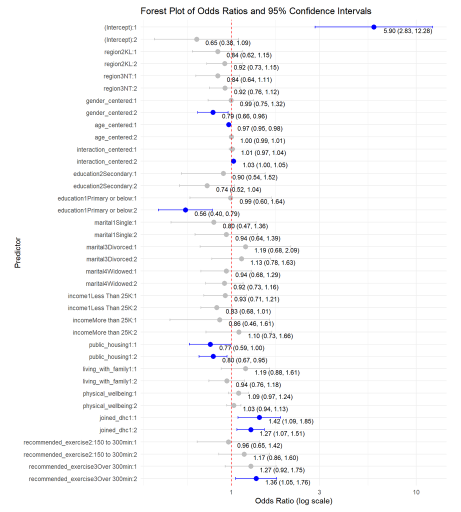

```r
create_forest_plot_vgam(cumulative_model_phy)
```

#### 4 Demographcs + eHealth

```r
cumulative_model_ehealth <- vglm(Dosage ~ region + gender_centered + age_centered +  education + marital + income +
                                   public_housing + living_with_family +
                                   eHEALS,
                             family = cumulative(link = "logitlink",parallel = FALSE, reverse = TRUE), data = covid)

summary(cumulative_model_ehealth)
```

```
##
## Call:
## vglm(formula = Dosage ~ region + gender_centered + age_centered +
##     education + marital + income + public_housing + living_with_family +
##     eHEALS, family = cumulative(link = "logitlink", parallel = FALSE,
##     reverse = TRUE), data = covid)
##
## Coefficients:
##                               Estimate Std. Error z value Pr(>|z|)
## (Intercept):1                 2.164921   0.335963   6.444 1.16e-10 ***
## (Intercept):2                -0.403852   0.225673  -1.790  0.07353 .
## region2KL:1                  -0.123266   0.159161  -0.774  0.43865
## region2KL:2                  -0.062959   0.112726  -0.559  0.57649
## region3NT:1                  -0.135825   0.139194  -0.976  0.32916
## region3NT:2                  -0.065331   0.095718  -0.683  0.49490
## gender_centered:1            -0.044771   0.137296  -0.326  0.74435
## gender_centered:2            -0.189579   0.094495  -2.006  0.04483 *
## age_centered:1               -0.039560   0.008586  -4.607 4.08e-06 ***
## age_centered:2               -0.003121   0.006229  -0.501  0.61628
## education2Secondary:1        -0.031442   0.267211  -0.118  0.90633
## education2Secondary:2        -0.186276   0.174123  -1.070  0.28471
## education1Primary or below:1  0.138080   0.263675   0.524  0.60050
## education1Primary or below:2 -0.404376   0.173422  -2.332  0.01971 *
## marital1Single:1             -0.372465   0.260726  -1.429  0.15313
## marital1Single:2             -0.011010   0.191679  -0.057  0.95420
## marital3Divorced:1            0.044130   0.281205   0.157  0.87530
## marital3Divorced:2            0.067381   0.184641   0.365  0.71516
## marital4Widowed:1            -0.115723   0.160838  -0.719  0.47183
## marital4Widowed:2            -0.087439   0.116964  -0.748  0.45472
## income1Less Than 25K:1       -0.122038   0.134345  -0.908  0.36367
## income1Less Than 25K:2       -0.202853   0.097650  -2.077  0.03777 *
## incomeMore than 25K:1        -0.069462   0.323081  -0.215  0.82977
## incomeMore than 25K:2         0.082337   0.210551   0.391  0.69576
## public_housing1:1            -0.364660   0.134208  -2.717  0.00659 **
## public_housing1:2            -0.223445   0.087678  -2.548  0.01082 *
## living_with_family1:1         0.110146   0.153884   0.716  0.47413
## living_with_family1:2        -0.050184   0.112277  -0.447  0.65490
## eHEALS:1                      0.010721   0.006363   1.685  0.09203 .
## eHEALS:2                      0.013586   0.004226   3.215  0.00131 **
## ---
```

[output cut: 19 more lines]

```
##                    0.9612127                    0.9968836                    0.9690467
##        education2Secondary:2 education1Primary or below:1 education1Primary or below:2
##                    0.8300444                    1.1480679                    0.6673934
##             marital1Single:1             marital1Single:2           marital3Divorced:1
##                    0.6890338                    0.9890506                    1.0451182
##           marital3Divorced:2            marital4Widowed:1            marital4Widowed:2
##                    1.0697031                    0.8907219                    0.9162745
##       income1Less Than 25K:1       income1Less Than 25K:2        incomeMore than 25K:1
##                    0.8851145                    0.8163979                    0.9328960
##        incomeMore than 25K:2            public_housing1:1            public_housing1:2
##                    1.0858214                    0.6944328                    0.7997591
##        living_with_family1:1        living_with_family1:2                     eHEALS:1
##                    1.1164409                    0.9510546                    1.0107783
##                     eHEALS:2
##                    1.0136788
```

```r
cumulative_ehealth_ci <- exp(confint(cumulative_model_ehealth, level = 0.95))
print(cumulative_ehealth_ci)
```

```
##                                  2.5 %     97.5 %
## (Intercept):1                4.5106666 16.8339304
## (Intercept):2                0.4290578  1.0392083
## region2KL:1                  0.6471250  1.2076592
## region2KL:2                  0.7528441  1.1711419
## region3NT:1                  0.6645531  1.1468165
## region3NT:2                  0.7765188  1.1300620
## gender_centered:1            0.7306160  1.2514774
## gender_centered:2            0.6874359  0.9956372
## age_centered:1               0.9451716  0.9775261
## age_centered:2               0.9847879  1.0091279
## education2Secondary:1        0.5739771  1.6360435
## education2Secondary:2        0.5900481  1.1676568
## education1Primary or below:1 0.6847421  1.9248997
## education1Primary or below:2 0.4750781  0.9375594
## marital1Single:1             0.4133422  1.1486066
## marital1Single:2             0.6792992  1.4400447
## marital3Divorced:1           0.6022866  1.8135420
## marital3Divorced:2           0.7448974  1.5361372
## marital4Widowed:1            0.6498848  1.2208095
## marital4Widowed:2            0.7285603  1.1523533
## income1Less Than 25K:1       0.6802132  1.1517384
## income1Less Than 25K:2       0.6741899  0.9886021
## incomeMore than 25K:1        0.4952516  1.7572783
## incomeMore than 25K:2        0.7186829  1.6405123
## public_housing1:1            0.5338164  0.9033759
## public_housing1:2            0.6734848  0.9497091
## living_with_family1:1        0.8257521  1.5094606
## living_with_family1:2        0.7631948  1.1851561
## eHEALS:1                     0.9982506  1.0234631
## eHEALS:2                     1.0053167  1.0221104
```

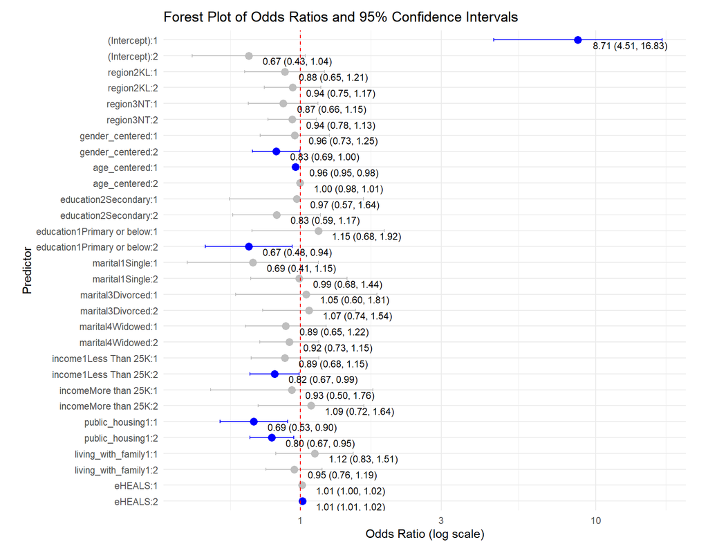

```r
create_forest_plot_vgam(cumulative_model_ehealth)
```